# Spatial SEIR Ebola Tutorial

Grant Brown

07/16/2014

The ongoing West Africa Ebola outbreak is an ongoing public health crisis, which has killed hundreds of people so far. The virus has emerged in Gunea, Liberia and Sierra Leone, complicating mitigation efforts.

A mirror of the WHO case reports is compiled on wikipedia - let’s read it in with the xml library. The case reports present cumulative case counts - due to the fact that these are sometimes revised downward, we need to take this into account when “uncumulating” the data.

```r
library(coda)
library(spatialSEIR)
library(XML)
url = 'http://en.wikipedia.org/wiki/2014_West_Africa_Ebola_outbreak'
tbls = readHTMLTable(url)
dat = tbls[[2]]

rptDate = as.Date(dat[2:nrow(dat),1], "%d %b %Y")
ascendingOrder = order(rptDate)
rptDate = rptDate[ascendingOrder][2:length(rptDate)]
Guinea = as.numeric(as.character(dat$V4[2:nrow(dat)]))[ascendingOrder]
Guinea = ifelse(is.na(Guinea), 0, Guinea)
Liberia = as.numeric(as.character(dat$V6[2:nrow(dat)]))[ascendingOrder]
Liberia = ifelse(is.na(Liberia), 0, Liberia)
Sierra.Leone = as.numeric(as.character(dat$V8[2:nrow(dat)]))[ascendingOrder]
Sierra.Leone = ifelse(is.na(Sierra.Leone), 0,Sierra.Leone)

uncumulate = function(x)
{
    out = x[2:length(x)]-x[1:(length(x)-1)]
    ifelse(out >= 0, out, 0)
}
I_star = cbind(uncumulate(Guinea), uncumulate(Liberia), uncumulate(Sierra.Leone))
```

The ebola outbreak started in February, though the exact date is difficult to pin down. Let’s assume that the cases reflected in the report originated in the time since the end of February. This allows us to calculate the ammount of time corresponding to each report.

```r
  offsets = rptDate- c(as.Date("2014-03-01"), rptDate[1:(length(rptDate)-1)])
```

All three of these countries share borders, so without more research on population flows we’re restricted to a fairly simple neighborhood distance structure.

```r
DM = 0.5*(1-diag(3))
```

With so few spatial locations, we’re limited in how many location specific variables we can entertain. While some demographic variables are easily obtained, for now let’s just fit a separate intercept for each spatial location.

```r
# Guinea, Liberia, Sierra Leone
N = matrix(c(10057975, 4128572, 6190280), nrow = nrow(I_star),ncol = 3, byrow=TRUE)

# Fixed Co-variates
X = cbind(diag(3))
# Time Varying co-variates
daysSinceJan = as.numeric(rptDate - as.Date("2014-01-01"))
# Use orthogonal polynomials for time basis

Z = poly(daysSinceJan, degree=3)


# We're going to want to do prediction, so let's generate the fixed and time varying co-variate matrices now
# before we modify Z
X.predict = cbind(diag(3))
Z.predict = predict.poly(Z, c(max(daysSinceJan) + 1, max(daysSinceJan) + seq(10,60,10)))


# These co-variates are the same for each spatial location, so duplicate them row-wise.
Z = Z[rep(1:nrow(Z), nrow(X)),]
Z.predict = Z.predict[rep(1:nrow(Z.predict), nrow(X)),]

# For convenience, let's combine X and Z for prediction.
X.pred = cbind(X.predict[rep(1:nrow(X.predict), each = nrow(Z.predict)/nrow(X)),], Z.predict)

# Define prediction offsets.

offset.pred = c(1,rep(10, 6))

# No reinfection, so use a dummy matrix for X_prs

X_p_rs = matrix(0)

# Get object dimensions. This will be done automatically in the future
compMatDim = dim(I_star)
xDim = dim(X)
zDim = dim(Z)
xPrsDim = dim(X_p_rs)



# Prior parameters.
priorAlpha_gammaEI = 25;
priorBeta_gammaEI = 100;
priorAlpha_gammaIR = 14;
priorBeta_gammaIR = 100;

# Dummy value for betaP_RS prior precision
betaPrsPriorPrecision = 0.5
# Dummy value for beta_p_rs
beta_p_rs = rep(0, ncol(X_p_rs))


# Prior precision for regression paramters
betaPriorPrecision = 0.01

# reinfection mode is 3, which forces S_star to remain 0.
reinfectionMode = 3

# steadyStateConstraintPrecision is a loose constraint on net flows
# between compartments. Setting it to a negative value eliminates
# the constraint, but it can help with identifiability in cases where
# there should be a long term equilibrium (endemic disease).
steadyStateConstraintPrecision = -1

# iterationStride determines the delay between saving samples to the
# output file
iterationStride = 1000

# Turn off verbose and debug output.
verbose = FALSE
debug = FALSE

# Starting tuning parameters for MCMC sampling
mcmcTuningParams = c(1, # S_star
                     1, # E_star
                     1,  # R_star
                     1,  # S_0
                     1,  # I_0
                     0.05,  # beta
                     0.0,  # beta_p_rs, fixed in this case
                     0.01, # rho
                     0.01, # gamma_ei
                     0.01) # gamma_ir

# Don't re-scale distance matrix.
scaleDistanceMode = 0
```

## Parameter Starting Values

In order to start multiple chains from different but reasonable starting points, let’s make a function to perform the requisite set up randomly.

```r
proposeParameters = function(seedVal, chainNumber)
{
    set.seed(seedVal)

    # 2 to 21 day incubation period according to who
    p_ei = 0.25 + rnorm(1, 0, 0.02)
    # Up to 7 weeks even after recovery
    p_ir = 0.14 + rnorm(1, 0, 0.01)
    gamma_ei=-log(1-p_ei)
    gamma_ir=-log(1-p_ir)

    # Starting value for exposure regression parameters
    beta = rep(0, ncol(X) + ncol(Z))
    beta[1] = 2.5 + rnorm(1,0,0.5)

    rho = 0.1 + rnorm(1,0,0.01) # spatial dependence parameter

    outFileName = paste("./chain_output_ebola_", chainNumber ,".txt", sep = "")

    # Make a crude guess as to the true compartments:
    # S_star, E_star, R_star, and thus S,E,I and R
    proposal = generateCompartmentProposal(I_star, N,
                                           S0 = N[1,]-I_star[1,] - c(10,0,0),
                                           I0 = c(10,0,0),
                                           p_ir = 0.5,
                                           p_rs = 0.00)

    return(list(S0=proposal$S0,
                E0=proposal$E0,
                I0=proposal$I0,
                R0=proposal$R0,
                S_star=proposal$S_star,
                E_star=proposal$E_star,
                I_star=proposal$I_star,
                R_star=proposal$R_star,
                rho=rho,
                beta=beta,
                gamma_ei=gamma_ei,
                gamma_ir=gamma_ir,
                outFileName=outFileName))
}
```

Now we’re ready to build, burn in, and run the models. We also need to tell libspatialSEIR to set a trace to keep track of the epidemic at each location in order to estimate the epidemic size.

```r
SEIRmodels = list()
i = 1;
for (seedVal in c(12345,543219,992134))
{
  proposal = proposeParameters(seedVal, i)
  SEIRmodels[[i]] = spatialSEIRModel(compMatDim,
                      xDim,
                      zDim,
                      xPrsDim,
                      proposal$S0,
                      proposal$E0,
                      proposal$I0,
                      proposal$R0,
                      proposal$S_star,
                      proposal$E_star,
                      proposal$I_star,
                      proposal$R_star,
                      offsets,
                      X,
                      Z,
                      X_p_rs,
                      DM,
                      proposal$rho,
                      priorAlpha_gammaEI,
                      priorBeta_gammaEI,
                      priorAlpha_gammaIR,
                      priorBeta_gammaIR,
                      proposal$beta,
                      betaPriorPrecision,
                      beta_p_rs,
                      betaPrsPriorPrecision,
                      proposal$gamma_ei,
                      proposal$gamma_ir,
                      N,
                      proposal$outFileName,
                      iterationStride,
                      steadyStateConstraintPrecision,
                      verbose,
                      debug,
                      mcmcTuningParams,
                      reinfectionMode,
                      scaleDistanceMode)

  i = i + 1;
}
```

[output not shown]

```r
# Track the last time point for each of the three locations
# in order to make predictions


SEIRmodels[[1]]$setTrace(0) #Guinea
```

```
## [1] 0
```

```r
SEIRmodels[[1]]$setTrace(1) #Liberia
```

```
## [1] 0
```

```r
SEIRmodels[[1]]$setTrace(2) #Sierra Leone
```

```
## [1] 0
```

Declare a helper function to run the simulation and update the sampling parameters periodically

```r
runSimulation = function(modelObject,
                         numBatches=500,
                         batchSize=20,
                         targetAcceptanceRatio=0.1,
                         tolerance=0.05,
                         proportionChange = 0.1
                        )
{
    for (batch in 1:numBatches)
    {
        modelObject$simulate(batchSize)
        modelObject$updateSamplingParameters(targetAcceptanceRatio, tolerance, proportionChange)
    }
}




for (i in 1:length(SEIRmodels))
{
    cat(paste("Burning in chain ", i, "\n", sep =""))
    runSimulation(SEIRmodels[[i]])
    SEIRmodels[[i]]$simulate(1000)
    SEIRmodels[[i]]$printAcceptanceRates()
}
```

```
## Burning in chain 1
## Total iterations so far: 11000
## Acceptance rates:
## S0:       0.119
## I0:       0.098
## S_star:   -nan
## E_star:   0.01
## R_star:   0.137
## beta:     0.082, 0.082, 0.082, 0.082, 0.082, 0.082,
## rho:      0.102
## betaP_RS: -nan,
## gamma_ei:     0.081
## gamma_ir:     0.107
## Burning in chain 2
## Total iterations so far: 11000
## Acceptance rates:
## S0:       0.119
## I0:       0.154
## S_star:   -nan
## E_star:   0.018
## R_star:   0.177
## beta:     0.103, 0.103, 0.103, 0.103, 0.103, 0.103,
## rho:      0.097
## betaP_RS: -nan,
## gamma_ei:     0.075
## gamma_ir:     0.111
## Burning in chain 3
## Total iterations so far: 11000
## Acceptance rates:
## S0:       0.119
## I0:       0.148
## S_star:   -nan
## E_star:   0.016
## R_star:   0.101
## beta:     0.113, 0.113, 0.113, 0.113, 0.113, 0.113,
## rho:      0.094
## betaP_RS: -nan,
## gamma_ei:     0.116
## gamma_ir:     0.1
```

Now we can run the chains. In practice, this is probably better done in separate R sessions so that the chains can be run at the same time. Note that if we were using the OpenCL features of libspatialSEIR, this would need to be done on separate machines.

```r
for (i in 1:length(SEIRmodels))
{
    cat(paste("Running in chain ", i, "\n", sep =""))
    tm = system.time(runSimulation(SEIRmodels[[i]],
                  numBatches=5,
                  batchSize=50000,
                  targetAcceptanceRatio=0.25,
                  tolerance=0.025,
                  proportionChange = 0.1))
    cat(paste("Time elapsed: ", round(tm[3]/60,3),
              " minutes\n", sep = ""))
}
```

```
## Running in chain 1
## Time elapsed: 1.525 minutes
## Running in chain 2
## Time elapsed: 1.586 minutes
## Running in chain 3
## Time elapsed: 1.593 minutes
```

Now let’s assess chain convergence.

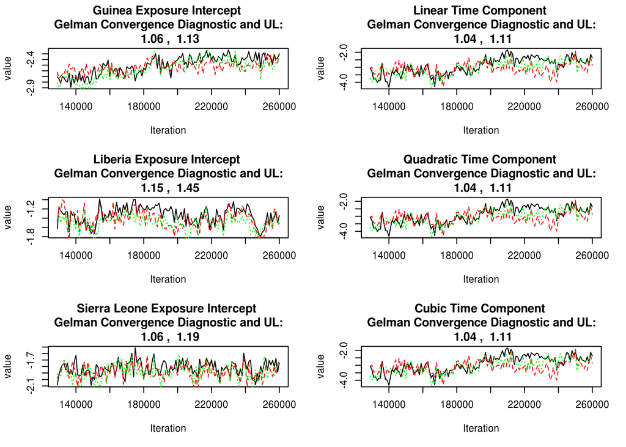

```r
chain1 = read.csv("chain_output_ebola_1.txt")
chain2 = read.csv("chain_output_ebola_2.txt")
chain3 = read.csv("chain_output_ebola_3.txt")

plotChains = function(c1, c2, c3, main)
{
    idx = floor(length(c1)/2):length(c1)
    mcl = mcmc.list(as.mcmc(c1),
                    as.mcmc(c2),
                    as.mcmc(c3))
    g.d = gelman.diag(mcl)
    main = paste(main, "\n", "Gelman Convergence Diagnostic and UL: \n",
                 round(g.d[[1]][1],2), ", ", round(g.d[[1]][2],2))

    plot(chain1$Iteration[idx], c1[idx], type = "l", main = main,
         xlab = "Iteration", ylab = "value")
    lines(chain2$Iteration[idx],c2[idx], col = "red", lty=2)
    lines(chain3$Iteration[idx],c3[idx], col = "green", lty=3)
}

# Guinea, Liberia, Sierra Leone
par(mfrow = c(3,2))
plotChains(chain1$BetaP_SE_0,
           chain2$BetaP_SE_0,
           chain3$BetaP_SE_0,
           "Guinea Exposure Intercept")
plotChains(chain1$BetaP_SE_3,
           chain2$BetaP_SE_3,
           chain3$BetaP_SE_3,
           "Linear Time Component")

plotChains(chain1$BetaP_SE_1,
           chain2$BetaP_SE_1,
           chain3$BetaP_SE_1,
           "Liberia Exposure Intercept")
plotChains(chain1$BetaP_SE_3,
           chain2$BetaP_SE_3,
           chain3$BetaP_SE_3,
           "Quadratic Time Component")

plotChains(chain1$BetaP_SE_2,
           chain2$BetaP_SE_2,
           chain3$BetaP_SE_2,
           "Sierra Leone Exposure Intercept")
plotChains(chain1$BetaP_SE_3,
           chain2$BetaP_SE_3,
           chain3$BetaP_SE_3,
           "Cubic Time Component")
```

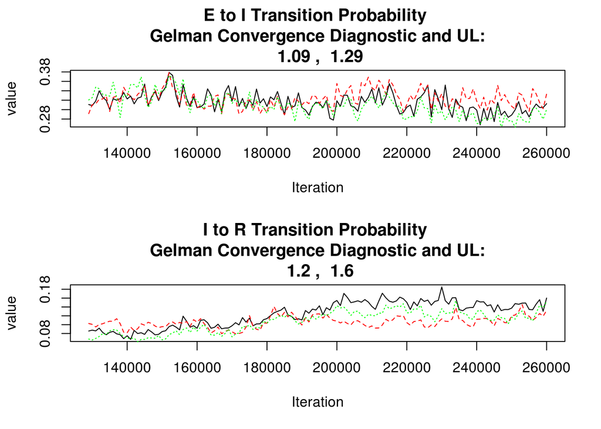

```r
par(mfrow = c(2,1))
plotChains(1-exp(-chain1$gamma_ei),
           1-exp(-chain2$gamma_ei),
           1-exp(-chain3$gamma_ei)
           , "E to I Transition Probability")
plotChains(1-exp(-chain1$gamma_ir),
           1-exp(-chain2$gamma_ir),
           1-exp(-chain3$gamma_ir)
           , "I to R Transition Probability")
```

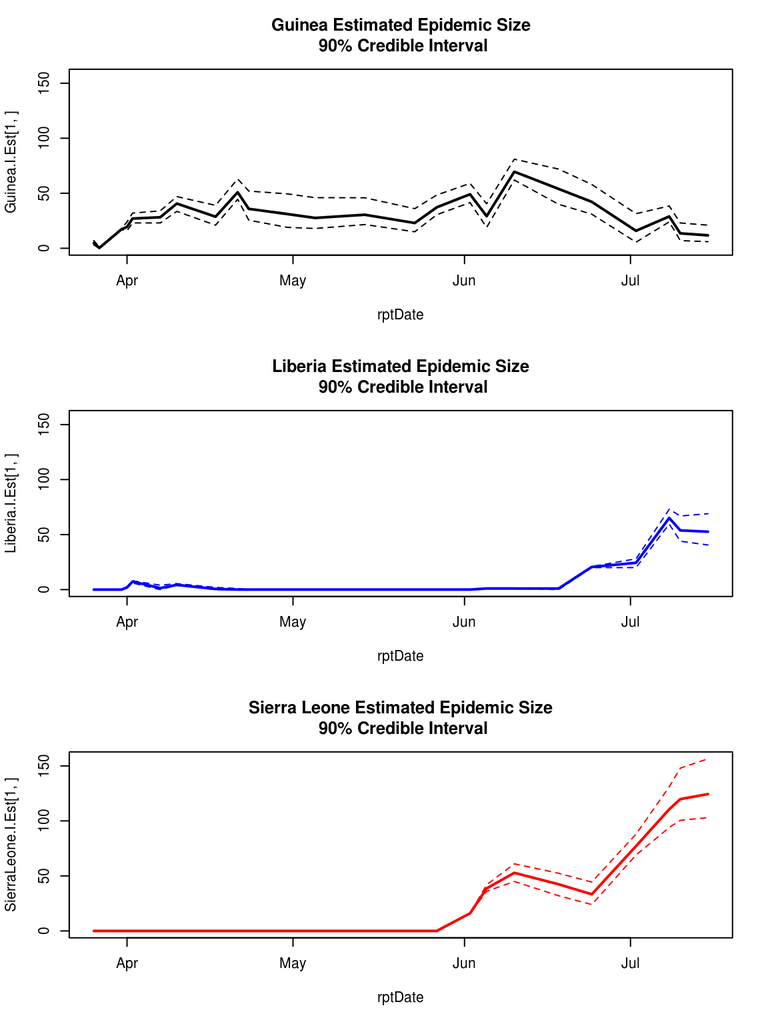

```r
getMeanAndCI = function(loc,tpt,baseStr="I_")
{
    vec = chain1[[paste(baseStr, loc, "_", tpt, sep = "")]]
    vec = vec[floor(length(vec)/2):length(vec)]
    return(c(mean(vec), quantile(vec, probs = c(0.05, 0.95))))
}

Guinea.I.Est = sapply(0:23, getMeanAndCI, loc=0)
Liberia.I.Est = sapply(0:23, getMeanAndCI, loc=1)
SierraLeone.I.Est = sapply(0:23, getMeanAndCI, loc=2)

maxI = max(c(Guinea.I.Est, Liberia.I.Est, SierraLeone.I.Est))
par(mfrow = c(3,1))
plot(rptDate, Guinea.I.Est[1,], ylim = c(0, maxI),
     main = "Guinea Estimated Epidemic Size\n 90% Credible Interval",
     type = "l", lwd = 2)
lines(rptDate, Guinea.I.Est[2,], lty = 2)
lines(rptDate, Guinea.I.Est[3,], lty = 2)

plot(rptDate, Liberia.I.Est[1,], ylim = c(0, maxI),
     main = "Liberia Estimated Epidemic Size\n 90% Credible Interval",
     type = "l", lwd = 2, col = "blue")
lines(rptDate, Liberia.I.Est[2,], lty = 2, col = "blue")
lines(rptDate, Liberia.I.Est[3,], lty = 2, col = "blue")

plot(rptDate, SierraLeone.I.Est[1,], ylim = c(0, maxI),
     main = "Sierra Leone Estimated Epidemic Size\n 90% Credible Interval",
     type = "l", lwd = 2, col = "red")
lines(rptDate, SierraLeone.I.Est[2,], lty = 2, col = "red")
lines(rptDate, SierraLeone.I.Est[3,], lty = 2, col ="red")
```

# Basic Reproductive Number

The basic reproductive number is a useful quantity which gives the expected number of secondary infections caused by a single infected individual. We did not calculate this value periodically throughout the MCMC samples so far, so in order to capture the variability in this measure we’ll need to run a few more samples.

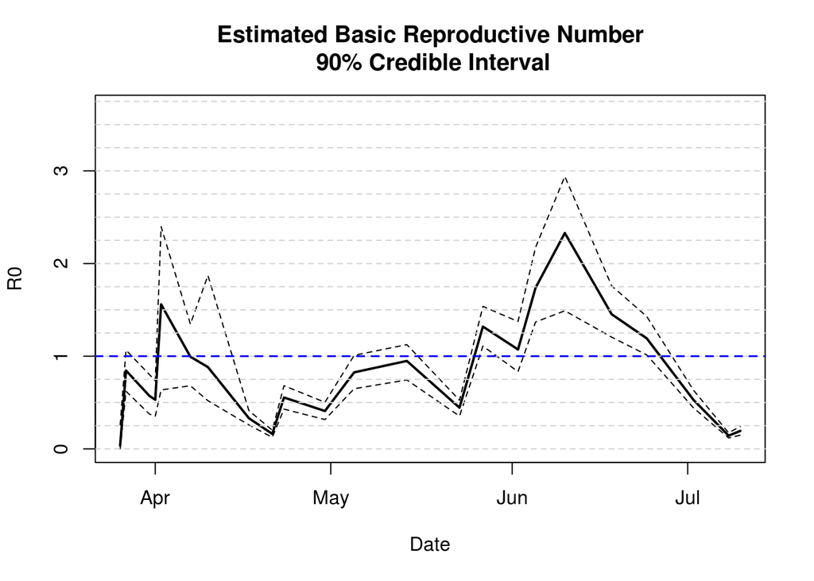

```r
  getR0 = function(t)
  {
    max(eigen(SEIRmodels[[1]]$getGenerationMatrix(t))$values)
  }

  R0_vec = sapply(1:(nrow(SEIRmodels[[1]]$I)-1), getR0)

  for (i in 1:200)
  {
      SEIRmodels[[1]]$simulate(500)
      R0_vec = rbind(R0_vec,sapply(1:(nrow(SEIRmodels[[1]]$I)-1), getR0))
  }

  r0.ylim = c(min(R0_vec), max(R0_vec))
  r0.meanvec = apply(R0_vec, 2, mean)
  r0.LB = apply(R0_vec, 2, quantile, probs = c(0.05))
  r0.UB = apply(R0_vec, 2, quantile, probs = c(0.95))

  plot(rptDate[1:(length(rptDate)-1)], r0.meanvec , type = "l", xlab = "Date",ylab = "R0",
       main = "Estimated Basic Reproductive Number\n 90% Credible Interval", ylim = r0.ylim,
       lwd = 2)
  lines(rptDate[1:(length(rptDate)-1)], r0.LB, lty = 2)
  lines(rptDate[1:(length(rptDate)-1)], r0.UB, lty = 2)
  abline(h=seq(0, 5, 0.25), lty=2, col="lightgrey")
  abline(h = 1.0, col = "blue", lwd = 1.5, lty = 2)
```

# Prediction

Prediction is a critical function of epidemic models like these. While prediction is not yet built into libspatialSEIR, we can run the chain binomial process forward in time from a number of starting positions given by the mcmc samples taken so far to obtain mean predictions and credible intervals.

```r
  predictEpidemic = function(beta.pred,
                             X.pred,
                             gamma.ei,
                             gamma.ir,
                             S0,
                             E0,
                             I0,
                             R0,
                             rho,
                             offsets.pred)
  {
      N = (S0+E0+I0+R0)
      p_se_components = matrix(exp(X.pred %*% beta.pred), ncol=length(S0))
      p_se = matrix(0, ncol = length(S0), nrow = nrow(p_se_components))
      p_ei = 1-exp(-gamma.ei*offsets.pred)
      p_ir = 1-exp(-gamma.ir*offsets.pred)
      S_star = matrix(0, ncol=length(S0),nrow = nrow(p_se_components))
      E_star = matrix(0, ncol=length(S0),nrow = nrow(p_se_components))
      I_star = matrix(0, ncol=length(S0),nrow = nrow(p_se_components))
      R_star = matrix(0, ncol=length(S0),nrow = nrow(p_se_components))
      S = matrix(0, ncol=length(S0),nrow = nrow(p_se_components))
      E = matrix(0, ncol=length(S0),nrow = nrow(p_se_components))
      I = matrix(0, ncol=length(S0),nrow = nrow(p_se_components))
      R = matrix(0, ncol=length(S0),nrow = nrow(p_se_components))
      S[1,] = S0
      E[1,] = E0
      I[1,] = I0
      R[1,] = R0
      S_star[1,] = rbinom(rep(1, length(S0)), R0, 0)
      p_se[1,] = 1-exp(-offsets.pred[1]*(I[1,]/N*p_se_components[1,] +
                            rho*(DM %*% (I[1,]/N*p_se_components[1,]))))
      E_star[1,] = rbinom(rep(1, length(S0)), S0, p_se[1,])
      I_star[1,] = rbinom(rep(1, length(S0)), E0, p_ei[1])
      R_star[1,] = rbinom(rep(1, length(S0)), I0, p_ir[1])

      for (i in 2:nrow(S))
      {

        S[i,] = S[i-1,] + S_star[i-1,] - E_star[i-1,]
        E[i,] = E[i-1,] + E_star[i-1,] - I_star[i-1,]
        I[i,] = I[i-1,] + I_star[i-1,] - R_star[i-1,]
        R[i,] = R[i-1,] + R_star[i-1,] - S_star[i-1,]

        p_se[i,] = 1-exp(-offsets.pred[i]*(I[i,]/N*p_se_components[i,] +
                            rho*(DM %*% (I[i,]/N*p_se_components[i,]))))
        S_star[i,] = rbinom(rep(1, length(S0)), R[i,], 0)
        E_star[i,] = rbinom(rep(1, length(S0)), S[i,], p_se[i,])
        I_star[i,] = rbinom(rep(1, length(S0)), E[i,], p_ei[i])
        R_star[i,] = rbinom(rep(1, length(S0)), I[i,], p_ir[i])
      }
      return(list(S=S,E=E,I=I,R=R,
                  S_star=S_star,E_star=E_star,
                  I_star=I_star,R_star=R_star,
                  p_se=p_se,p_ei=p_ei,p_ir=p_ir))
  }


  predict.i = function(i)
  {
    dataRow = chain1[i,]
    rho = dataRow$rho
    beta = c(dataRow$BetaP_SE_0,
             dataRow$BetaP_SE_1,
             dataRow$BetaP_SE_2,
             dataRow$BetaP_SE_3,
             dataRow$BetaP_SE_4,
             dataRow$BetaP_SE_5)
    S0 = c(dataRow$S_0_23 - dataRow$E_star_0_23,
           dataRow$S_1_23 - dataRow$E_star_1_23,
           dataRow$S_2_23 - dataRow$E_star_2_23)
    E0 = c(dataRow$E_0_23 + dataRow$E_star_0_23 - dataRow$I_star_0_23,
           dataRow$E_1_23 + dataRow$E_star_1_23 - dataRow$I_star_1_23,
           dataRow$E_2_23 + dataRow$E_star_2_23 - dataRow$I_star_2_23)
    I0 = c(dataRow$I_0_23 + dataRow$I_star_0_23 - dataRow$R_star_0_23,
           dataRow$I_1_23 + dataRow$I_star_1_23 - dataRow$R_star_1_23,
           dataRow$I_2_23 + dataRow$I_star_2_23 - dataRow$R_star_2_23)
    R0 = c(dataRow$R_0_23 + dataRow$R_star_0_23,
           dataRow$R_1_23 + dataRow$R_star_1_23,
           dataRow$R_2_23 + dataRow$R_star_2_23)
    return(predictEpidemic(beta,
                           X.pred,
                           dataRow$gamma_ei,
                           dataRow$gamma_ir,
                           S0,
                           E0,
                           I0,
                           R0,
                           rho,
                           offset.pred
                           ))
  }

  preds = lapply((nrow(chain1) - floor(nrow(chain1)/2)):
                   nrow(chain1), predict.i)
```

With the predictions made, we need a way to visualize them. For illustrative purposes, return to the estimated epidemic plot, but include predictions for the next sixty days.

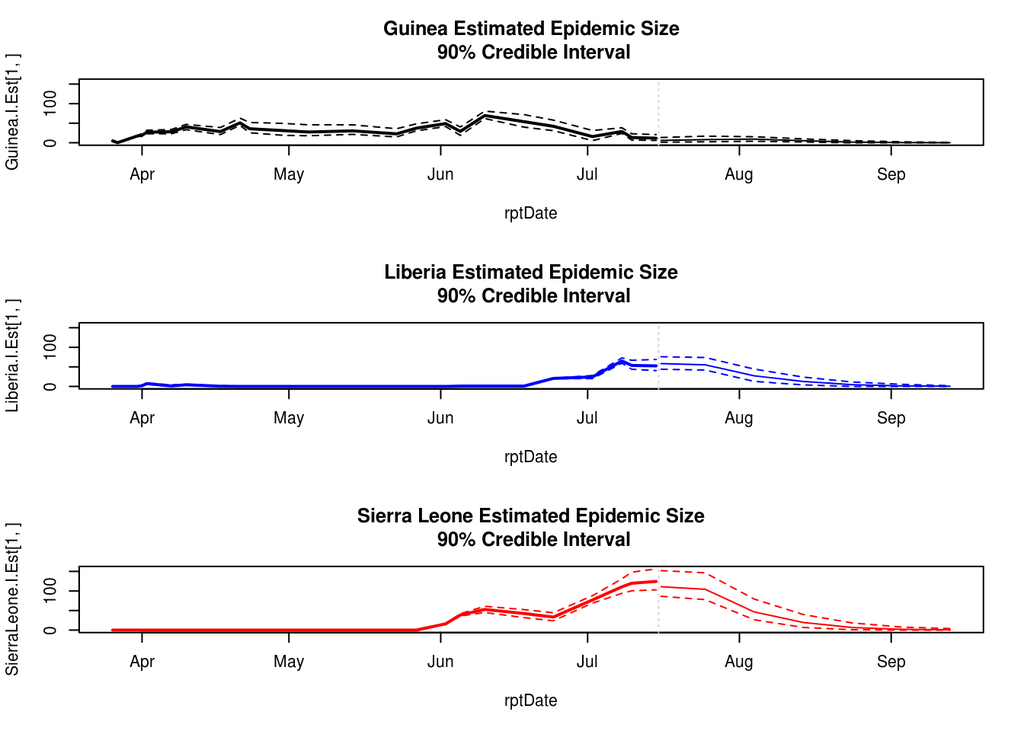

```r
pred.dates = c(rptDate[(which.max(rptDate))] + 1,rptDate[(which.max(rptDate))] + seq(10,60,10))
pred.xlim = c(min(rptDate), max(pred.dates))
lastIdx = nrow(SEIRmodels[[1]]$I)
Guinea.Pred = preds[[1]]$I[,1]
Liberia.Pred = preds[[1]]$I[,2]
SierraLeone.Pred = preds[[1]]$I[,3]

breakpoint = mean(c(max(rptDate), min(pred.dates)))

for (predIdx in 2:length(preds))
{
   Guinea.Pred = rbind(Guinea.Pred, preds[[predIdx]]$I[,1])
   Liberia.Pred = rbind(Liberia.Pred, preds[[predIdx]]$I[,2])
   SierraLeone.Pred = rbind(SierraLeone.Pred, preds[[predIdx]]$I[,3])
}

Guinea.mean = apply(Guinea.Pred, 2, mean)
Liberia.mean = apply(Liberia.Pred, 2, mean)
SierraLeone.mean = apply(SierraLeone.Pred, 2, mean)

Guinea.LB = apply(Guinea.Pred, 2, quantile, probs = c(0.05))
Guinea.UB = apply(Guinea.Pred, 2, quantile, probs = c(0.95))

Liberia.LB = apply(Liberia.Pred, 2, quantile, probs = c(0.05))
Liberia.UB = apply(Liberia.Pred, 2, quantile, probs = c(0.95))

SierraLeone.LB = apply(SierraLeone.Pred, 2, quantile, probs = c(0.05))
SierraLeone.UB = apply(SierraLeone.Pred, 2, quantile, probs = c(0.95))





## Guinea
par(mfrow = c(3,1))
plot(rptDate, Guinea.I.Est[1,], ylim = c(0, maxI), xlim = pred.xlim,
     main = "Guinea Estimated Epidemic Size\n 90% Credible Interval",
     type = "l", lwd = 2)
lines(rptDate, Guinea.I.Est[2,], lty = 2)
lines(rptDate, Guinea.I.Est[3,], lty = 2)

lines(pred.dates,Guinea.mean,
        lty=1, col = "black", lwd = 1)
lines(pred.dates,Guinea.LB,
        lty=2, col = "black", lwd = 1)
lines(pred.dates,Guinea.UB,
        lty=2, col = "black", lwd = 1)
abline(v = breakpoint, lty = 3, col= "lightgrey")

## Liberia
plot(rptDate, Liberia.I.Est[1,], ylim = c(0, maxI),  xlim = pred.xlim,
     main = "Liberia Estimated Epidemic Size\n 90% Credible Interval",
     type = "l", lwd = 2, col = "blue")
lines(rptDate, Liberia.I.Est[2,], lty = 2, col = "blue")
lines(rptDate, Liberia.I.Est[3,], lty = 2, col = "blue")

lines(pred.dates,Liberia.mean,
        lty=1, col = "blue", lwd = 1)
lines(pred.dates,Liberia.LB,
        lty=2, col = "blue", lwd = 1)
lines(pred.dates,Liberia.UB,
        lty=2, col = "blue", lwd = 1)
abline(v = breakpoint, lty = 3, col= "lightgrey")

## Sierra Leone
plot(rptDate, SierraLeone.I.Est[1,], ylim = c(0, maxI),  xlim = pred.xlim,
     main = "Sierra Leone Estimated Epidemic Size\n 90% Credible Interval",
     type = "l", lwd = 2, col = "red")
lines(rptDate, SierraLeone.I.Est[2,], lty = 2, col = "red")
lines(rptDate, SierraLeone.I.Est[3,], lty = 2, col ="red")

lines(pred.dates,SierraLeone.mean,
        lty=1, col = "red", lwd = 1)
lines(pred.dates,SierraLeone.LB,
        lty=2, col = "red", lwd = 1)
lines(pred.dates,SierraLeone.UB,
        lty=2, col = "red", lwd = 1)
abline(v = breakpoint, lty = 3, col= "lightgrey")
```